# National Instructor Written Practical Examination CIB

National-Interstate Council of State Boards of Cosmetology (NIC)

Effective Date: June 01, 2024 Revision Date: January 01, 2026

## CANDIDATE INFORMATION BULLETIN (CIB)

**EXAMINATION CONTENT AND IMPORTANT INSTRUCTIONS**

*Please visit your official examination provider website OR www.nictesting.org for the most current bulletin prior to testing.*

The National Instructor Written Practical Examination is a licensure examination for Instructor, developed by the National-Interstate Council of State Boards of Cosmetology (NIC).

This bulletin contains IMPORTANT INFORMATION regarding National Instructor Written Practical Examination content and administration for core services and additional sections and references.

The time allowed for this examination is 90 minutes.

*PLEASE REVIEW ALL INFORMATION CAREFULLY.*

For each NIC National Written Practical Examination, there are multiple parts to every Candidate Information Bulletin (CIB):

- **Important Instructions and Examination Content Domain Sections** – This provides information and guidelines related to administration of the Written Practical examination and information about the scope of content covered in the Written Practical examination.
- **References** – This provides a list of references used to develop and support the content covered in NIC examinations. References will be the same for Theory, Practical, Written Practical, and Additional Sections for each exam.

*BE CERTAIN TO REVIEW ALL PARTS OF THIS NIC EXAMINATION CIB CAREFULLY!*

## IMPORTANT INSTRUCTIONS

### General

- Do not leave the examination area without permission. Permission must be obtained to leave the examination area for any reason, including restroom usage or at the completion of the examination. *Picture ID is required for re-entry into the examination.*
- All examinations are administered in a testing environment.

### Standardized Administration

Due to standardization of the NIC National Examinations, proctors and examiners are required to adhere to the following standards:

- With the exception of verbal instructions, proctors and examination administration personnel are NOT allowed to speak with candidates.
- If a candidate experiences an emergency situation, they may notify the proctor by raising their hand.

#### Prohibited Items

- The following provides examples of materials and actions that are prohibited in the examination room during the examination administration:
  - Possession of cellular phones, watches (of any kind), pagers, tablets, computers, projectors, cameras, or any other electronic or recording devices, printed materials, or handwritten notes.
  - Purses, bags, coats, hats, and any other personal items not directly needed to complete the examination, are not allowed.
- Communicating to other candidates or any examiner.
- Exhibiting disruptive behavior. The above referenced items or actions are not an exhaustive list.

Failure to comply with any of these conditions or exhibiting ANY behavior that suggests an effort to cheat will result in immediate dismissal from the examination and the candidates’ actions reported to the proper authorities.

## INSTRUCTOR WRITTEN PRACTICAL EXAMINATION CONTENT OUTLINE

### Domain Details

The following outlines the scope of content covered by the NIC National Instructor Written Practical Examination. The percentages represent the percentage of items from each domain. The examination contains 55 items, of which 45 items are weighted and contribute to the candidate’s final score. The Core Domain Sections are based on the national job analysis.

1. Lesson Plan(19%)
2. Theory Lecture(43%)
3. Demonstration(38%)

The following outlines the scope of content covered by the NIC National Instructor Written Practical Examination. The steps covering procedures you are expected to know are listed for each section. The lesson plan topic is Infection Control and includes the Blood Exposure Procedure. You are tested on your knowledge of instruction of the topic, infection control procedures, and the blood exposure procedure throughout the exam.

1. Lesson Plan (19%)
   1. Lesson plan elements:
      1. Lesson plan introduction
      2. Lesson plan content
      3. Teaching aids
      4. Closing
2. Theory Lecture (43%)
   1. Lecture elements:
      1. Sets up area for classroom theory lecture
      2. Introduction to lecture
      3. Content of lecture
      4. Lectures on Blood Exposure Procedure
      5. Use of teaching aids
      6. Use of communication skills
      7. Classroom interaction
      8. Evaluation of lecture
      9. Closing of lecture
      10. Safety and infection control
3. Demonstration (38%)
   1. Demonstration elements:
      1. Sets up area for demonstration
      2. Introduction to demonstration
      3. Content of demonstration
      4. Performance of demonstration
      5. Demonstrates Blood Exposure Procedure
      6. Classroom interaction
      7. Closing of demonstration
      8. Places items to be disinfected, soiled linens, and trash in correct containers

## NATIONAL INSTRUCTOR WRITTEN PRACTICAL EXAMINATION SAMPLE QUESTIONS

1. What should be included in a lesson plan?

   A. Syllabus

   B. Grading methods

   C. Course outline

   D. Teaching aids

2. Put the following steps of a draping for a haircut in order.

   A. Lean client back, place towel over neck, secure cape, place towel over cape

   B. Place towel over neck, secure cape, place towel over cape lean client back

   C. Secure cape, place towel over cape, place towel over neck, lean client back

   D. Place towel over neck, secure cape, lean client back, place towel over cape

3. Where should used combs be placed?

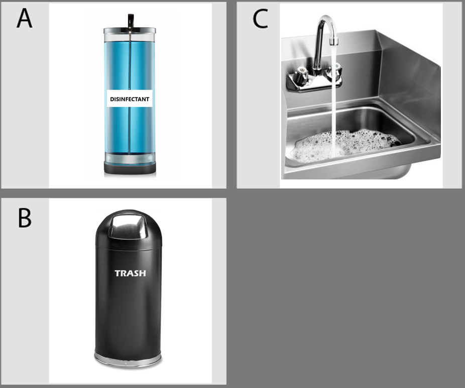

4. Which first aid supplies are ready to use?

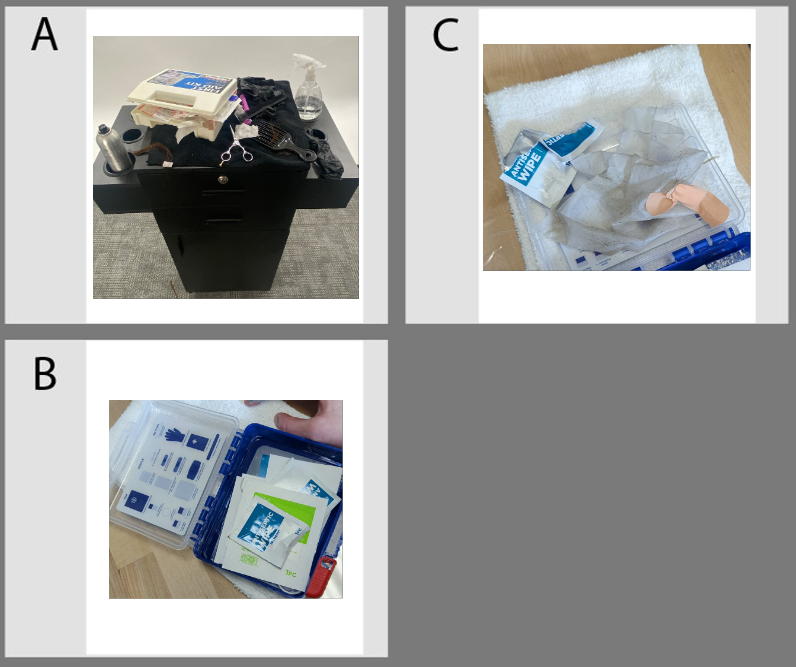

**Answer Key**

| Item | Key |
| --- | --- |
| 1 | D |
| 2 | A |
| 3 | C |
| 4 | B |

## NATIONAL-INTERSTATE COUNCIL OF STATE BOARDS OF COSMETOLOGY (NIC) REFERENCES

This list provides the references used to develop and support the content covered in the NIC National Instructor examinations. References will be the same across exam types for each exam. Candidates are responsible for using these most updated versions of references, as these editions were used to reference test material.

Reference Date: January 01, 2026

### Standard

*Milady Professional Educator*

Copyrighted 2022

2022, 4th Edition

ISBN: 9781337786836

Milady www.Milady.com

Contact: Info@Milady.com;

*McKeachie’s Teaching Tips: Strategies, Research, and Theory for College and University Teachers 2014, 14th Edition*

Copyrighted 2014

2014, 14th Edition

Milady www.Milady.com

Milady Contact: Info@Milady.com;

*Fundamentals: Mindful Teaching*

Copyrighted 2025

2nd Edition

978-1-962998-31-4

Pivot Point International, Inc. www.pivot-point.com

Contact: info@pivot-point.com; 847-886-0500

### Supplemental

*Mindful Teaching Pro eBook (101.1 – 701.6)*

Copyrighted 2023

1st Edition

Pivot Point International, Inc. www.pivot-point.com

Contact: info@pivot-point.com; 847-886-0500

Copyright 2024 National-Interstate Council of State Boards of Cosmetology, Inc.